# Анализ эффективности рекламных источников вопросе привлечения пользователей в игру "Космические братья"

# **Ссылка на презентацию:** https://disk.yandex.ru/i/6XI6kHdp1CXcOw

# **Ссылка на дашборд:** https://public.tableau.com/views/_16660397154440/Dashboard1?:language=en-GB&publish=yes&:display_count=n&:origin=viz_share_link

**Введение**

Исследование посвящено анализу данных активности пользователей игры "Космические братья", которые пришли в игру по 4 рекламным источникам с 4 по 10 мая. Цель исследования - выявить оптимальный рекламный источник, а также изучить использование игроками базовых игровых механик на первом уровне.

**Ключевые выводы по результатам анализа:**

- 43% пользователей достигли первого уровня и продолжили играть что можно считать хорошим результатом.
- 2/3 пользователей выбирали способ получения уровня через победу на врагом.
- Стоимость привлечения каждого пользователя сильно выше у ФБ и Инстаграмма, ниже у Яндекс Директа и Ютуба.
- Было обнаружено падение ROI из-за того, что пользователи строят все меньше зданий типа "сборочный цех".
- Была обнаружена незначительная разница игрового времени между получившими уровень и теми, кто бросил игру до этого момента, то есть если бы уровень можно было бы получить несколько раньше, вероятность сохранения этих клиентов могла бы возрасти.
- Были протестированы гипотезы о разнице среднего игрового времени и среднего количества построенных зданий в зависимости от способа прохождения. В итоге было выявлено, что пользователи, проходящие первый уровень через реализацию проекта играют дольше, но при этом смотрят и больше рекламы.

**Рекомендации заказчику:**

- Оптимальные источнкии для вложения рекламных бюджетов - Яндекс Директ и ЮТуб.
- Возможно потребуется исправить игровой дисбаланс между способами прохождения. Может быть прохождение через проект хоть и будет приносить потенциально больше рекламных денег, скорее оттолкнет игроков длинным временем прохождения.
- Геймдизайнерам необходимо изучить причины, по которым игроки строят все меньше зданий типа "сборочный цех", возможно они считают их бесполезными. Это требует корректировки внутригрового баланса. Рекомендуется проведение внутреннее тестирование силами тестировщиков клиента, возможен опрос пользователей.
- **Рекомендуем провести эксперимент (A|B тестирование)** на тестовой группе протестировать ускоренный сценарий прохождения уровня через проект, чтобы понять, повысит ли это конверсию игроков на следующий уровень и увеличит ли продолжительность их игры, а также приведет ли это в конечном счете к росту ROI.

**Оглавление:**

1. Подготовка к анализу
2. Подготовка данных
   - Поиск и исправление ошибок в данных
   - Формирование датафреймов для анализа
3. Исследовательский анализ данных
   - Общее описание данных
4. Сравнение эффективности рекламных источников
5. Тестирование исследовательских гипотез
   - Различие времени игры в зависимости от способа прохождения
   - Различие количества числа просмотренных рекламных объявлений в зависимости от способа прохождения
6. Итоговые выводы и рекомендации

## Подготовка к анализу

В данном разделе мы подгрузим библиотеки и массивы данных, проведем первичный их анализ.

```python
#Подгружаем библиотеки
import pandas as pd
import matplotlib as mpl
import matplotlib.pyplot as plt
import numpy as np
import seaborn as sns
from scipy import stats as st
import datetime as dt
```

```python
sns.set(rc={'figure.figsize':(12,9)})
```

```python
pd.set_option('display.precision', 3)
pd.options.display.max_colwidth = 1
```

```python
#функция для подгрузки массивов с гугл диска
def google_downloader(url):
    file_id=url.split('/')[-2]
    dwn_url='https://drive.google.com/uc?id=' + file_id
    df = pd.read_csv(dwn_url, parse_dates = True)
    return df
```

```python
#Подгружаем массивы
ad_costs = google_downloader('https://drive.google.com/file/d/1CBYJ2ikij7VECsLhjKT9bH7RiuSkllxe/view?usp=sharing')
game_actions = google_downloader('https://drive.google.com/file/d/1fy5Qz3GU9Lm2HaEgERpNbtrVIhJzP81Q/view?usp=sharing')
user_source = google_downloader('https://drive.google.com/file/d/18qw9cBnNultfvlS-f2L1FELqBLnpU84_/view?usp=sharing')
```

```python
ad_costs
```

|  | source | day | cost |
| --- | --- | --- | --- |
| 0 | facebook_ads | 2020-05-03 | 935.883 |
| 1 | facebook_ads | 2020-05-04 | 548.354 |
| 2 | facebook_ads | 2020-05-05 | 260.186 |
| 3 | facebook_ads | 2020-05-06 | 177.982 |
| 4 | facebook_ads | 2020-05-07 | 111.767 |
| 5 | facebook_ads | 2020-05-08 | 68.009 |
| 6 | facebook_ads | 2020-05-09 | 38.723 |
| 7 | instagram_new_adverts | 2020-05-03 | 943.205 |
| 8 | instagram_new_adverts | 2020-05-04 | 502.925 |
| 9 | instagram_new_adverts | 2020-05-05 | 313.971 |
| 10 | instagram_new_adverts | 2020-05-06 | 173.071 |
| 11 | instagram_new_adverts | 2020-05-07 | 109.915 |
| 12 | instagram_new_adverts | 2020-05-08 | 71.579 |
| 13 | instagram_new_adverts | 2020-05-09 | 46.775 |
| 14 | yandex_direct | 2020-05-03 | 969.139 |
| 15 | yandex_direct | 2020-05-04 | 554.651 |
| 16 | yandex_direct | 2020-05-05 | 308.233 |
| 17 | yandex_direct | 2020-05-06 | 180.917 |
| 18 | yandex_direct | 2020-05-07 | 114.429 |
| 19 | yandex_direct | 2020-05-08 | 62.962 |
| 20 | yandex_direct | 2020-05-09 | 42.780 |
| 21 | youtube_channel_reklama | 2020-05-03 | 454.225 |
| 22 | youtube_channel_reklama | 2020-05-04 | 259.073 |
| 23 | youtube_channel_reklama | 2020-05-05 | 147.042 |
| 24 | youtube_channel_reklama | 2020-05-06 | 88.506 |
| 25 | youtube_channel_reklama | 2020-05-07 | 55.741 |
| 26 | youtube_channel_reklama | 2020-05-08 | 40.218 |
| 27 | youtube_channel_reklama | 2020-05-09 | 23.315 |

Первый массив представляет собой данные по совокупным ежедневным тратам для каждого рекламного источника, всего их 4:

- Фейсбук
- Инстаграмм
- Яндекс Директ
- Ютуб

Также мы сразу видим, что реклама оплачивается авансом, т.е. 3го мая платили за 4ое, 4го - за 5ое и т.д., дату надо будет перенести на день вперед, чтобы было удобно объединять.

```python
game_actions
```

|  | event_datetime | event | building_type | user_id | project_type |
| --- | --- | --- | --- | --- | --- |
| 0 | 2020-05-04 00:00:01 | building | assembly_shop | 55e92310-cb8e-4754-b622-597e124b03de | NaN |
| 1 | 2020-05-04 00:00:03 | building | assembly_shop | c07b1c10-f477-44dc-81dc-ec82254b1347 | NaN |
| 2 | 2020-05-04 00:00:16 | building | assembly_shop | 6edd42cc-e753-4ff6-a947-2107cd560710 | NaN |
| 3 | 2020-05-04 00:00:16 | building | assembly_shop | 92c69003-d60a-444a-827f-8cc51bf6bf4c | NaN |
| 4 | 2020-05-04 00:00:35 | building | assembly_shop | cdc6bb92-0ccb-4490-9866-ef142f09139d | NaN |
| ... | ... | ... | ... | ... | ... |
| 135635 | 2020-06-05 00:08:06 | building | research_center | f21d179f-1c4b-437e-b9c6-ab1976907195 | NaN |
| 135636 | 2020-06-05 02:25:12 | finished_stage_1 | NaN | 515c1952-99aa-4bca-a7ea-d0449eb5385a | NaN |
| 135637 | 2020-06-05 08:57:52 | building | research_center | ed3e7d02-8a96-4be7-9998-e9813ff9c316 | NaN |
| 135638 | 2020-06-05 12:12:27 | finished_stage_1 | NaN | 32572adb-900f-4b5d-a453-1eb1e6d88d8b | NaN |
| 135639 | 2020-06-05 12:32:49 | finished_stage_1 | NaN | f21d179f-1c4b-437e-b9c6-ab1976907195 | NaN |

135640 rows × 5 columns

```python
game_actions['project_type'].unique()
```

```
array([nan, 'satellite_orbital_assembly'], dtype=object)
```

```python
game_actions[game_actions['project_type'] == game_actions['project_type']]['event'].unique()
```

```
array(['project'], dtype=object)
```

Второй массив - лог действий каждого игрока вплоть до повышения уровня (если игрок его повысил). В столбце project_type замечено наличие пропусков - видим, что значение там появляется только в момент действия проект и принимает ровно одно значение, т.е. этот столбец нам по факту не очень нужен.

```python
user_source
```

|  | user_id | source |
| --- | --- | --- |
| 0 | 0001f83c-c6ac-4621-b7f0-8a28b283ac30 | facebook_ads |
| 1 | 00151b4f-ba38-44a8-a650-d7cf130a0105 | yandex_direct |
| 2 | 001aaea6-3d14-43f1-8ca8-7f48820f17aa | youtube_channel_reklama |
| 3 | 001d39dc-366c-4021-9604-6a3b9ff01e25 | instagram_new_adverts |
| 4 | 002f508f-67b6-479f-814b-b05f00d4e995 | facebook_ads |
| ... | ... | ... |
| 13571 | ffef4fed-164c-40e1-bde1-3980f76d0fb5 | instagram_new_adverts |
| 13572 | fffab3da-da0e-4e30-ae62-10d0a2e24a4e | facebook_ads |
| 13573 | fffb626c-5ab6-47c9-8113-2062a2f18494 | yandex_direct |
| 13574 | ffff194a-56b7-4c12-860d-3485242ae7f5 | instagram_new_adverts |
| 13575 | ffff69cc-fec1-4fd3-9f98-93be1112a6b8 | facebook_ads |

13576 rows × 2 columns

Источник привлечения для каждого User ID. Также здесь мы впервые видим ориентировочный объем нашей выборки - 13 576 пользователей.

Вернуться к оглавлению

## Подготовка данных

В данном разделе будет проведена работа по поиску и исправлению ошибок в данных, а также по формированию новых объединенных датафреймов в подходящем для анализа формате.

### Поиск и исправление ошибок в данных

```python
ad_costs.info()
```

```
<class 'pandas.core.frame.DataFrame'>
RangeIndex: 28 entries, 0 to 27
Data columns (total 3 columns):
 #   Column  Non-Null Count  Dtype
---  ------  --------------  -----
 0   source  28 non-null     object
 1   day     28 non-null     object
 2   cost    28 non-null     float64
dtypes: float64(1), object(2)
memory usage: 800.0+ bytes
```

Видим, что дата в неправильном формате, к тому же, как мы уже говорили, необходимо прибавить к ней 1 день.

```python
ad_costs['day'] = pd.to_datetime(ad_costs['day'], format = '%Y-%m-%dT%H:%M:%S')
```

```python
ad_costs['day'] = ad_costs['day'] + pd.DateOffset(1)
```

```python
ad_costs.head()
```

|  | source | day | cost |
| --- | --- | --- | --- |
| 0 | facebook_ads | 2020-05-04 | 935.883 |
| 1 | facebook_ads | 2020-05-05 | 548.354 |
| 2 | facebook_ads | 2020-05-06 | 260.186 |
| 3 | facebook_ads | 2020-05-07 | 177.982 |
| 4 | facebook_ads | 2020-05-08 | 111.767 |

Итак, тип данных исправлен, даты подкорректированы, на том с этим массивом можно закончить.

```python
game_actions.info()
```

```
<class 'pandas.core.frame.DataFrame'>
RangeIndex: 135640 entries, 0 to 135639
Data columns (total 5 columns):
 #   Column          Non-Null Count   Dtype
---  ------          --------------   -----
 0   event_datetime  135640 non-null  object
 1   event           135640 non-null  object
 2   building_type   127957 non-null  object
 3   user_id         135640 non-null  object
 4   project_type    1866 non-null    object
dtypes: object(5)
memory usage: 5.2+ MB
```

Очевидно надо поменять здесь тип данных для даты, также мы видим наличие пропусков в building_type - их надо будет расследовать, пропуски в project_type мы уже описывали как вызванные структурой данных и потому неудалимые.

```python
game_actions['event_datetime'] = pd.to_datetime(game_actions['event_datetime'], format = '%Y-%m-%dT%H:%M:%S')
```

```python
display(game_actions[game_actions['building_type'].isna()])
```

|  | event_datetime | event | building_type | user_id | project_type |
| --- | --- | --- | --- | --- | --- |
| 6659 | 2020-05-04 19:47:29 | finished_stage_1 | NaN | ced7b368-818f-48f6-9461-2346de0892c5 | NaN |
| 13134 | 2020-05-05 13:22:09 | finished_stage_1 | NaN | 7ef7fc89-2779-46ea-b328-9e5035b83af5 | NaN |
| 15274 | 2020-05-05 18:54:37 | finished_stage_1 | NaN | 70db22b3-c2f4-43bc-94ea-51c8d2904a29 | NaN |
| 16284 | 2020-05-05 21:27:29 | finished_stage_1 | NaN | 903fc9ef-ba97-4b12-9d5c-ac8d602fbd8b | NaN |
| 19650 | 2020-05-06 06:02:22 | finished_stage_1 | NaN | 58e077ba-feb1-4556-a5a0-d96bd04efa39 | NaN |
| ... | ... | ... | ... | ... | ... |
| 135632 | 2020-06-04 15:50:38 | finished_stage_1 | NaN | 22cce310-fe10-41a2-941b-9c3d63327fea | NaN |
| 135633 | 2020-06-04 17:56:14 | finished_stage_1 | NaN | d477dde8-7c22-4f23-9c4f-4ec31a1aa4c8 | NaN |
| 135636 | 2020-06-05 02:25:12 | finished_stage_1 | NaN | 515c1952-99aa-4bca-a7ea-d0449eb5385a | NaN |
| 135638 | 2020-06-05 12:12:27 | finished_stage_1 | NaN | 32572adb-900f-4b5d-a453-1eb1e6d88d8b | NaN |
| 135639 | 2020-06-05 12:32:49 | finished_stage_1 | NaN | f21d179f-1c4b-437e-b9c6-ab1976907195 | NaN |

7683 rows × 5 columns

```python
game_actions[game_actions['building_type'].isna()]['event'].value_counts()
```

```
finished_stage_1    5817
project             1866
Name: event, dtype: int64
```

Тип данных изменен, также мы видим, что пропуски в building_type вызваны особенностью данных - они соответствуют действиям игрока, не связанным со строительством: повышение уровня или же завершение проекта.

```python
user_source.info()
```

```
<class 'pandas.core.frame.DataFrame'>
RangeIndex: 13576 entries, 0 to 13575
Data columns (total 2 columns):
 #   Column   Non-Null Count  Dtype
---  ------   --------------  -----
 0   user_id  13576 non-null  object
 1   source   13576 non-null  object
dtypes: object(2)
memory usage: 212.2+ KB
```

Пропуски отсутствуют, неправильные типы данных тоже. Вообще в дальнейшем можно будет заменить тип данных у переменной source на категориальный, но так как он потенциально может вызвать некоторые сложности в работе, мы этого пока делать не будем, так как размер наших данных не очень большой и много места в памяти они не занимают.

Далее проверим наши массивы на дубликаты - нас интересуют данные по логам и источникам пользователей, в ad_costs по очевидным причинам дубликатов нет.

```python
game_actions[game_actions.duplicated()]
```

|  | event_datetime | event | building_type | user_id | project_type |
| --- | --- | --- | --- | --- | --- |
| 74891 | 2020-05-10 18:41:56 | building | research_center | c9af55d2-b0ae-4bb4-b3d5-f32aa9ac03af | NaN |

Обнаружен один очевидный дубликат, удалим его.

```python
game_actions = game_actions.drop_duplicates().reset_index(drop = True)
```

Проверим неочевидные дубликаты. В силу того, может быть дублировались действия по строительству зданий как в дубликате выше, только в разное время.

```python
game_actions.drop('event_datetime', axis = 1).duplicated().sum()
```

```
93478
```

Похоже, что дубликаты есть, то есть на игроков приходится больше одного здания каждого типа, но ввиду того, что такие строки составляют более половины массива, они не дубликаты, а элемент механики игры, как во многих стратегия здания строятся по несколько штук.

```python
game_actions[game_actions.drop('event_datetime', axis = 1).duplicated()]
```

|  | event_datetime | event | building_type | user_id | project_type |
| --- | --- | --- | --- | --- | --- |
| 162 | 2020-05-04 00:30:27 | building | assembly_shop | 5118f7c5-0e54-4e46-afa6-1c7c8899a5ff | NaN |
| 233 | 2020-05-04 00:46:04 | building | assembly_shop | e97645cd-309f-42f9-8a2c-928540e76e63 | NaN |
| 296 | 2020-05-04 00:57:04 | building | assembly_shop | 92e9ba5d-c7d2-4297-979f-3c1065a13082 | NaN |
| 350 | 2020-05-04 01:05:31 | building | assembly_shop | 072c58ad-1501-434b-b38b-ce221cf4f12c | NaN |
| 388 | 2020-05-04 01:13:37 | building | assembly_shop | 1cc63c6c-54ac-4a36-b28d-1d012f32b127 | NaN |
| ... | ... | ... | ... | ... | ... |
| 135622 | 2020-06-03 20:17:34 | building | research_center | 32572adb-900f-4b5d-a453-1eb1e6d88d8b | NaN |
| 135623 | 2020-06-03 22:49:24 | building | spaceport | 515c1952-99aa-4bca-a7ea-d0449eb5385a | NaN |
| 135624 | 2020-06-04 01:30:46 | building | spaceport | 22cce310-fe10-41a2-941b-9c3d63327fea | NaN |
| 135626 | 2020-06-04 05:18:54 | building | research_center | d477dde8-7c22-4f23-9c4f-4ec31a1aa4c8 | NaN |
| 135630 | 2020-06-04 13:26:25 | building | research_center | 32572adb-900f-4b5d-a453-1eb1e6d88d8b | NaN |

93478 rows × 5 columns

```python
game_actions.pivot_table(index = 'user_id', columns = 'building_type', values = 'event', aggfunc = 'count', margins = True)
```

| building_type user_id | assembly_shop | research_center | spaceport | All |
| --- | --- | --- | --- | --- |
| 0001f83c-c6ac-4621-b7f0-8a28b283ac30 | 6.0 | 1.0 | 6.0 | 13 |
| 00151b4f-ba38-44a8-a650-d7cf130a0105 | 4.0 | NaN | 5.0 | 9 |
| 001aaea6-3d14-43f1-8ca8-7f48820f17aa | 2.0 | NaN | 2.0 | 4 |
| 001d39dc-366c-4021-9604-6a3b9ff01e25 | 4.0 | NaN | 4.0 | 8 |
| 002f508f-67b6-479f-814b-b05f00d4e995 | 3.0 | 1.0 | 8.0 | 12 |
| ... | ... | ... | ... | ... |
| fffab3da-da0e-4e30-ae62-10d0a2e24a4e | 5.0 | 3.0 | 8.0 | 16 |
| fffb626c-5ab6-47c9-8113-2062a2f18494 | 4.0 | 2.0 | 3.0 | 9 |
| ffff194a-56b7-4c12-860d-3485242ae7f5 | 6.0 | NaN | 1.0 | 7 |
| ffff69cc-fec1-4fd3-9f98-93be1112a6b8 | 3.0 | 3.0 | 6.0 | 12 |
| All | 54494.0 | 14137.0 | 59325.0 | 127956 |

13577 rows × 4 columns

**Итого, типы данных исправлены, удален 1 дубликат, нужды в удалении пропусков нет - они все вызваны особенностью данных.**

Вернуться к оглавлению

### Формирование датафреймов для анализа

Далее нам нужна сводная таблица по игрокам, в которой в соответствии с планом исследования у нас должны быть:

- **Дата первого действия в игре**, будем считать ее как дату прихода в игру, для понимания, к какой когорте по дате привлечения он относится. Также потом из нее можно будет рассчитать еще одну таблицу, из который мы сможем извлечь CAC.
- **Дата последнего действия в игре** для рассчета лайфтайма игроков на первом уровне.
- **Количество и типы построенных зданий** для рассчета LTV и ROI, а также анализа поведения игроков.
- **Источник привлечения** для анализа рекламных источников - получим через объединение сводной таблицы с таблицей user_source.
- **Статус и тип левелапа** - перешел ли игрок на следующий уровень и как он это сделал

Также нужна сводная по каждом дню изучаемого периода с информацией о количестве активных пользователей для рассчета DAU и WAU.

```python
game_actions.info()
```

```
<class 'pandas.core.frame.DataFrame'>
RangeIndex: 135639 entries, 0 to 135638
Data columns (total 5 columns):
 #   Column          Non-Null Count   Dtype
---  ------          --------------   -----
 0   event_datetime  135639 non-null  datetime64[ns]
 1   event           135639 non-null  object
 2   building_type   127956 non-null  object
 3   user_id         135639 non-null  object
 4   project_type    1866 non-null    object
dtypes: datetime64[ns](1), object(4)
memory usage: 5.2+ MB
```

```python
game_actions.columns
```

```
Index(['event_datetime', 'event', 'building_type', 'user_id', 'project_type'], dtype='object')
```

```python
#добавляем столбец с уникальными значениями для удобства подсчетов
game_actions = game_actions.reset_index()
game_actions.columns = ['log_id', 'event_datetime', 'event', 'building_type', 'user_id', 'project_type']
```

```python
#Собираем сводную таблицу с первым и последним действием в игре, а также с количеством построенных зданий
df_dates = game_actions.pivot_table(index = 'user_id',
                              values = 'event_datetime',
                              aggfunc = ['first', 'last'])
#переставляем айди в обычную колонку, чтобы легче потом было объединять
df_dates = df_dates.reset_index()

#переименовываем столбцы
df_dates.columns = ['user_id', 'first_action', 'last_action']
```

```python
#Собираем сводную таблицу с количеством построенных зданий
df_actions = game_actions.pivot_table(index = 'user_id',
                                      columns = 'event',
                                      values = 'log_id',
                                      aggfunc = 'count')
#переставляем айди в обычную колонку, чтобы легче потом было объединять
df_actions = df_actions.reset_index()

#переименовываем столбцы
df_actions.columns = ['user_id', 'num_buildings', 'level_up', 'project_done']
```

```python
#Собираем сводную таблицу с типами построенных зданий
df_buildings = game_actions.pivot_table(index = 'user_id',
                                      columns = 'building_type',
                                      values = 'log_id',
                                      aggfunc = 'count')
#переставляем айди в обычную колонку, чтобы легче потом было объединять
df_buildings = df_buildings.reset_index()
```

```python
df_users = df_actions.merge(df_dates, on = 'user_id')
df_users = df_users.merge(df_buildings, on = 'user_id')
df_users = df_users.merge(user_source, on = 'user_id')
```

Объединяем все таблицы вместе и получаем единый датафрейм для всех пользователей.

```python
#Приводим даты к нормальному виду
df_users['first_action'] = df_users['first_action'].dt.date
df_users['last_action'] = df_users['last_action'].dt.date
```

```python
df_users['first_action'] = pd.to_datetime(df_users['first_action'], format = '%Y-%m-%d')
df_users['last_action'] = pd.to_datetime(df_users['last_action'], format = '%Y-%m-%d')
```

Сразу же посчитаем лайфтайм для каждого пользователя

```python
df_users['life_time'] = df_users['last_action'] - df_users['first_action']
df_users['life_time'] = df_users['life_time'].dt.days
```

Создадим таблицу для числа уникальных пользователей, которые были привлечены в каждый из дней

```python
new_users = (
        df_users.groupby(['first_action', 'source'])
        .agg({'user_id': 'nunique'})
        .reset_index()
    )

new_users.columns = ['day', 'source', 'unique_users']
```

```python
new_users['day'] = pd.to_datetime(new_users['day'], format = '%Y-%m-%d')
```

```python
ad_costs = ad_costs.merge(new_users, on =['source', 'day'], how = 'left')
```

```python
ad_costs['acquisition_cost'] = ad_costs['cost'] / ad_costs['unique_users']
```

Все объединяем и рассчитываем стоимость привлечения одного пользователя

```python
df_users = df_users.merge(ad_costs[['source', 'day', 'acquisition_cost']], how = 'left', left_on = ['first_action', 'source'], right_on = ['day', 'source'])
```

```python
df_users = df_users.drop('day', axis = 1)
```

Также заменим значения в столбцах, чтобы отделить получивших первый уровень игроков от тех, кто его не получил, а также разделим по типу победы или ее отсутствия.

```python
df_users['level_up'][df_users['level_up'] == 1] = 'Yes'
df_users['level_up'][df_users['level_up'] != df_users['level_up']] = 'No'
```

```python
df_users['project_done'][df_users['project_done'] == 1] = 'Project'
df_users['project_done'][(df_users['project_done'] != df_users['project_done']) & (df_users['level_up'] == 'Yes')] = 'Defeat_enemy'
df_users['project_done'][df_users['level_up'] == 'No'] = 'No_level_up'
```

```python
df_users.columns = ['user_id', 'num_buildings', 'level_up', 'type_of_winning', 'first_action',
       'last_action', 'assembly_shop', 'research_center', 'spaceport',
       'source', 'life_time','acquisition_cost']
```

```python
df_users.head()
```

|  | user_id | num_buildings | level_up | type_of_winning | first_action | last_action | assembly_shop | research_center | spaceport | source | life_time | acquisition_cost |
| --- | --- | --- | --- | --- | --- | --- | --- | --- | --- | --- | --- | --- |
| 0 | 0001f83c-c6ac-4621-b7f0-8a28b283ac30 | 13.0 | No | No_level_up | 2020-05-06 | 2020-05-20 | 6.0 | 1.0 | 6.0 | facebook_ads | 14 | 0.754 |
| 1 | 00151b4f-ba38-44a8-a650-d7cf130a0105 | 9.0 | No | No_level_up | 2020-05-06 | 2020-05-18 | 4.0 | NaN | 5.0 | yandex_direct | 12 | 0.464 |
| 2 | 001aaea6-3d14-43f1-8ca8-7f48820f17aa | 4.0 | No | No_level_up | 2020-05-05 | 2020-05-14 | 2.0 | NaN | 2.0 | youtube_channel_reklama | 9 | 0.391 |
| 3 | 001d39dc-366c-4021-9604-6a3b9ff01e25 | 8.0 | Yes | Defeat_enemy | 2020-05-05 | 2020-05-12 | 4.0 | NaN | 4.0 | instagram_new_adverts | 7 | 0.632 |
| 4 | 002f508f-67b6-479f-814b-b05f00d4e995 | 12.0 | No | No_level_up | 2020-05-05 | 2020-05-22 | 3.0 | 1.0 | 8.0 | facebook_ads | 17 | 0.790 |

Также создадим таблицу для анализа пользовательской активности по дням

```python
#Приводим даты к нормальному виду
game_actions['event_datetime'] = game_actions['event_datetime'].dt.date
game_actions['event_datetime'] = pd.to_datetime(game_actions['event_datetime'], format = '%Y-%m-%d')
```

```python
dau_table = game_actions.pivot_table(index = 'event_datetime', values = 'user_id', aggfunc = 'nunique')
```

Вернуться к оглавлению

## Исследовательский анализ данных

В данном разделе мы переведем таблицу из логов действий пользователей в сводную таблицу по пользователям для последующего расчета интересующих нас метрик.

Ниже приведен перечень потенциальных метрик, которые будут использованы в рамках исследования.  
**Потенциальные экономические метрики:**

- **CAC** - Стоимость привлечения одного игрока (при допущении, что конверсия у нас 100%).
- **Количество построенных зданий** - косвенная метрика, предварительно позволяющая оценить эффективность монетизации, искусственный заменитель LTV - позволяет оценить эффективность предлагаемой модели монетизации.
- **(Количество построенных зданий)/CAC** - искусственный заменитель ROI, позволяет предположить сколько объявлений надо показать игроку при стоимости объявления 1, чтобы привлечение игрока окупалось, должен быть выше 1 (идею можно развить, добавив в уравнение переменную Х - выручку с одной показанной рекламы, но это уже не наша задача).  
  **Потенциальные метрики для оценки пользовательской активности:**
- **DAU** для рассчета посещаемости.
- **Конверсия в первый уровень** (рассчет доли тех, кто в итоге совершил левелап).  
  **Дополнительно:**
- Типовая последовательность действий и построек у пользователей.

Вернуться к оглавлению

### Общее описание данных

Итак, для начала подготовим общее описание данных. Создадим специальную функцию для общего обзора всех переменных.

```python
def des_var(data):
    for i in list(data):
        if (data[i].dtypes!='object') and (data[i].nunique() > 20):
             display (data[i].describe())
        else:
            display (data[i].value_counts())
        print ('------------------------------')
        print (' ')
```

```python
des_var(df_users)
```

```
0001f83c-c6ac-4621-b7f0-8a28b283ac30    1
a9ff93bd-0b96-4e89-bef7-c29326643faf    1
aa08dc9a-f199-483d-aa43-2781abb889fc    1
aa0d0a62-0ba5-4d87-9467-4eb39d6b2d17    1
aa122ae2-5e98-4d93-96dc-fdcf7016398e    1
                                       ..
53c5f5cc-975b-4be6-9a60-2a8fe0fc226f    1
53d146cf-1b2a-4038-8326-7900b021f418    1
53d59f09-9745-4bdd-b6e5-56f98a5228d4    1
53d8dfd2-d601-461b-a4fd-890be5b45d27    1
ffff69cc-fec1-4fd3-9f98-93be1112a6b8    1
Name: user_id, Length: 13576, dtype: int64
```

```
10.0    1436
11.0    1362
6.0     1319
9.0     1314
12.0    1229
13.0    1007
5.0     991
8.0     843
14.0    813
4.0     782
3.0     556
15.0    555
16.0    361
7.0     319
2.0     278
17.0    216
18.0    93
1.0     57
19.0    35
20.0    10
Name: num_buildings, dtype: int64
```

```
No     7759
Yes    5817
Name: level_up, dtype: int64
```

```
No_level_up     7759
Defeat_enemy    3951
Project         1866
Name: type_of_winning, dtype: int64
```

```
2020-05-04    5860
2020-05-05    3361
2020-05-06    1847
2020-05-07    1109
2020-05-08    688
2020-05-09    440
2020-05-10    271
Name: first_action, dtype: int64
```

```
count     13576
unique    33
top       2020-05-16 00:00:00
freq      1360
first     2020-05-04 00:00:00
last      2020-06-05 00:00:00
Name: last_action, dtype: object
```

```
7.0    1972
3.0    1966
5.0    1948
6.0    1940
1.0    1936
4.0    1924
2.0    1890
Name: assembly_shop, dtype: int64
```

```
1.0    3501
2.0    2404
3.0    1297
4.0    408
5.0    61
Name: research_center, dtype: int64
```

```
4.0     1767
2.0     1752
1.0     1699
5.0     1664
3.0     1659
6.0     1562
7.0     1422
8.0     1058
9.0     513
10.0    135
Name: spaceport, dtype: int64
```

```
yandex_direct              4817
instagram_new_adverts      3347
facebook_ads               2726
youtube_channel_reklama    2686
Name: source, dtype: int64
```

```
count    13576.000
mean     10.630
std      4.361
min      0.000
25%      8.000
50%      10.000
75%      13.000
max      31.000
Name: life_time, dtype: float64
```

```
count    13576.000
mean     0.560
std      0.144
min      0.391
25%      0.459
50%      0.466
75%      0.650
max      0.810
Name: acquisition_cost, dtype: float64
```

```python
#Функция для построения пирожковых диаграмм по сводным таблицам
def pie_cat(df, category, value, name):
    temp_df = df.pivot_table(index = category, values = value, aggfunc = 'count')
    temp_df.plot.pie(y=value, figsize=(10, 10), autopct="%.1f%%")
    plt.title('Доля {} в общем объеме выборки'.format(name))
    plt.show()
```

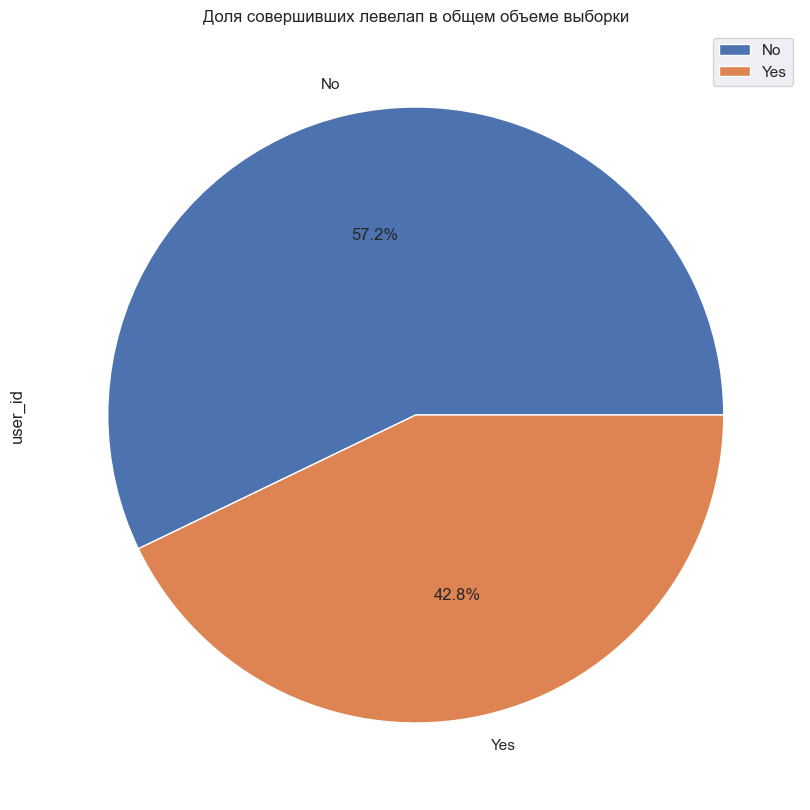

```python
pie_cat(df_users, 'level_up', 'user_id', 'совершивших левелап')
```

Итак, мы видим, что почти 43% привлеченных пользователей совершают левел-ап, что можно считать неплохим результатом.

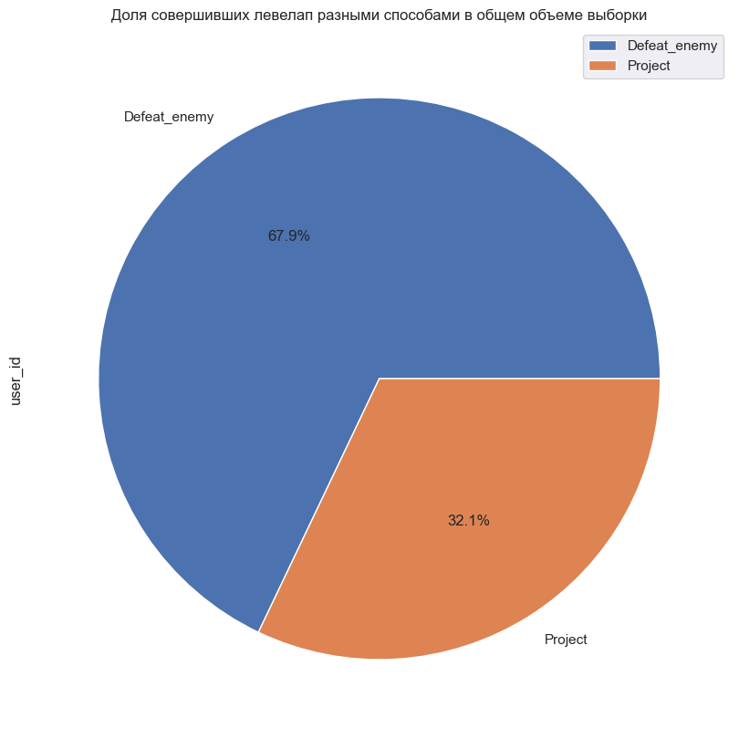

```python
pie_cat(df_users[df_users['type_of_winning'] != 'No_level_up'], 'type_of_winning', 'user_id', 'совершивших левелап разными способами')
```

2/3 игроков получают 1 уровень, победив врага, завершение проекта - гораздо менее популярный сценарий.

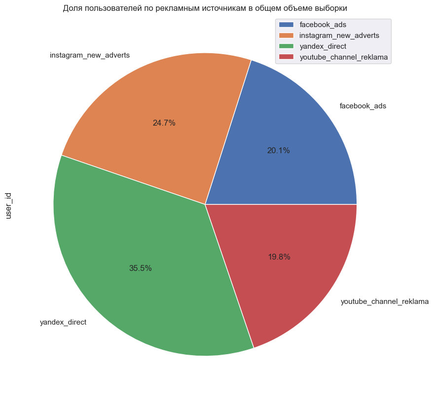

```python
pie_cat(df_users, 'source', 'user_id', 'пользователей по рекламным источникам')
```

Яндекс директ - самый популярный источник новых пользователей, занимающий вторую строчку инстаграмм сильное ему отступает.

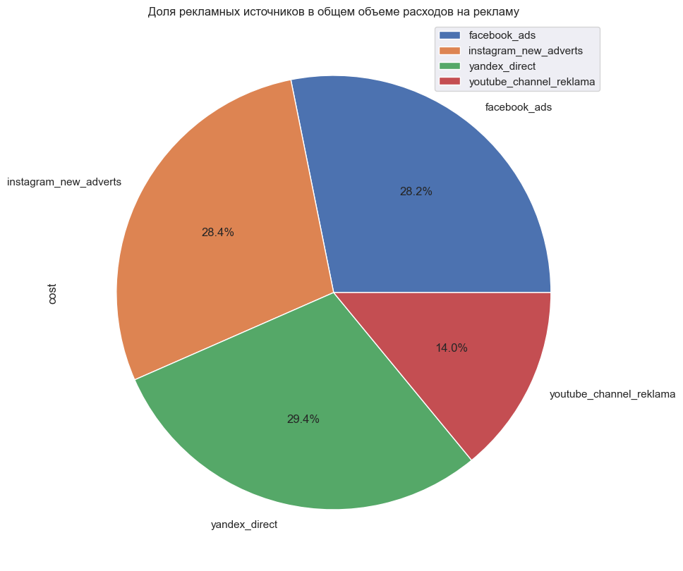

```python
ad_costs.pivot_table(index = 'source', values = 'cost', aggfunc = 'sum').plot.pie(y='cost', figsize=(10, 10), autopct="%.1f%%")
plt.title('Доля рекламных источников в общем объеме расходов на рекламу')
plt.show()
```

Сравнивая рекламные источники по количеству потраченных денег, мы сразу видим несколько другие пропорции, которые в первую очередь говорят не в пользу ФБ.

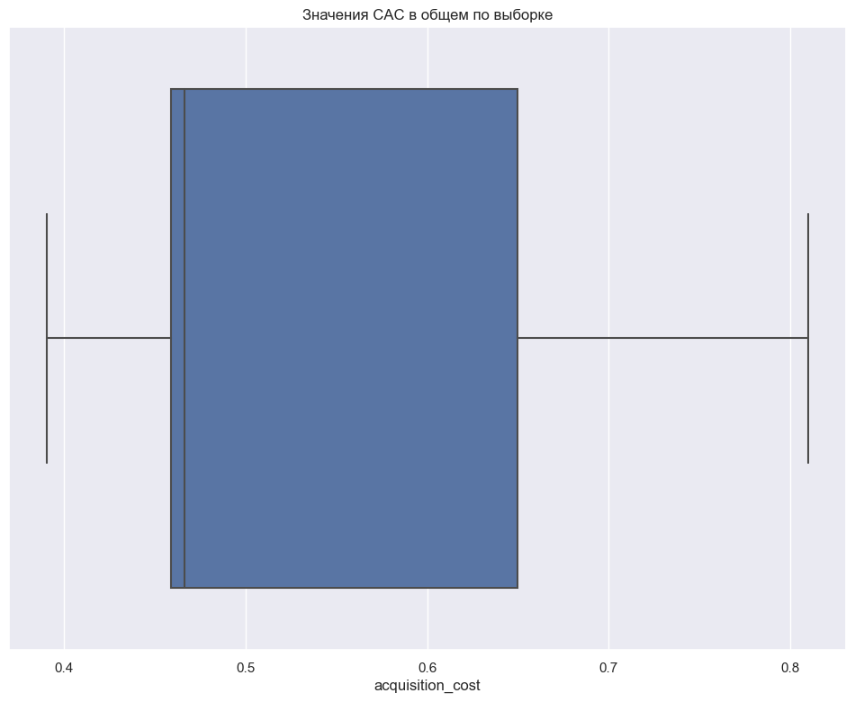

```python
sns.boxplot(df_users['acquisition_cost'])
plt.title('Значения CAC в общем по выборке')
plt.show()
```

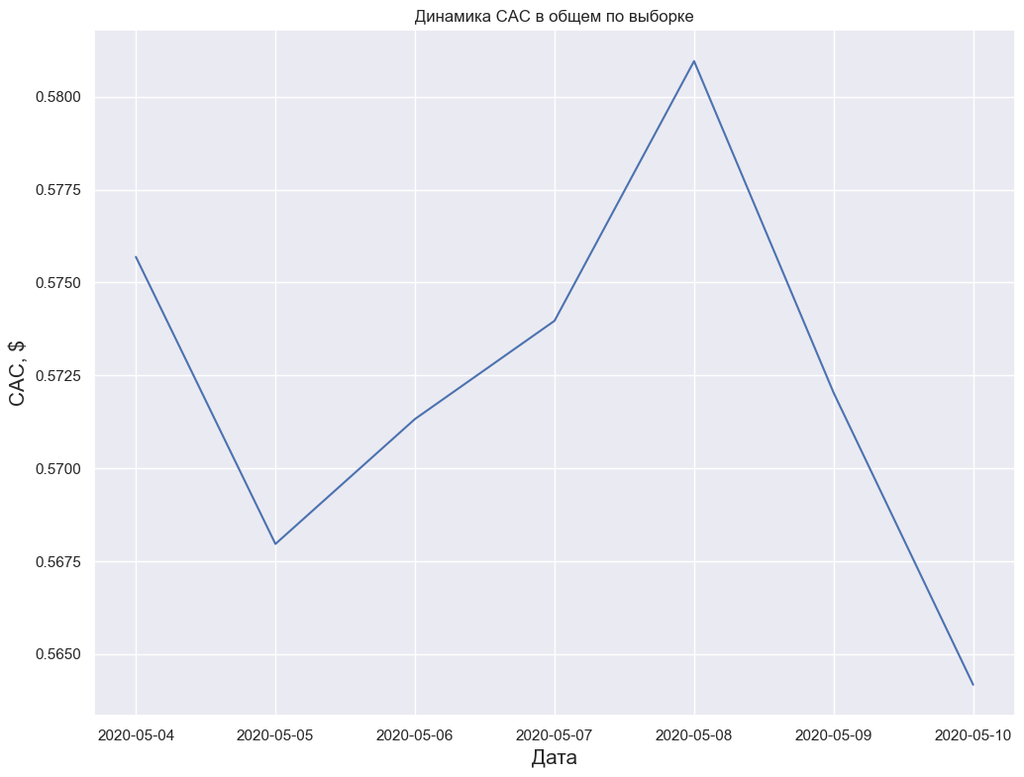

```python
ax = sns.lineplot(data = ad_costs.groupby(by = 'day').agg('mean'), x = 'day', y = 'acquisition_cost')
ax.set_xlabel('Дата', fontsize=15)
ax.set_ylabel('CAC, $', fontsize=15)
plt.title('Динамика CAC в общем по выборке')
plt.show()
```

На графиках выше представлен разброс стоимости привлечения одного клиента в целом за период, а также в динамике. Как мы видим, медианная стоимость привлечения находится ниже 0,5 доллара, при этом колебание среднего значения происходит в диапазоне от 0,565 до 0,58 долларов. С одной стороны это демонстрирует нам, что сильных колебаний во времени не было, с другой показывает, что у части рекламных источников привлечение явно стоит очень дорого и они оттягиваю средний показатель вверх. Более подробный разбор в разрезе по источникам будет представлен ниже в разеделе "Сравнение рекламных источников".

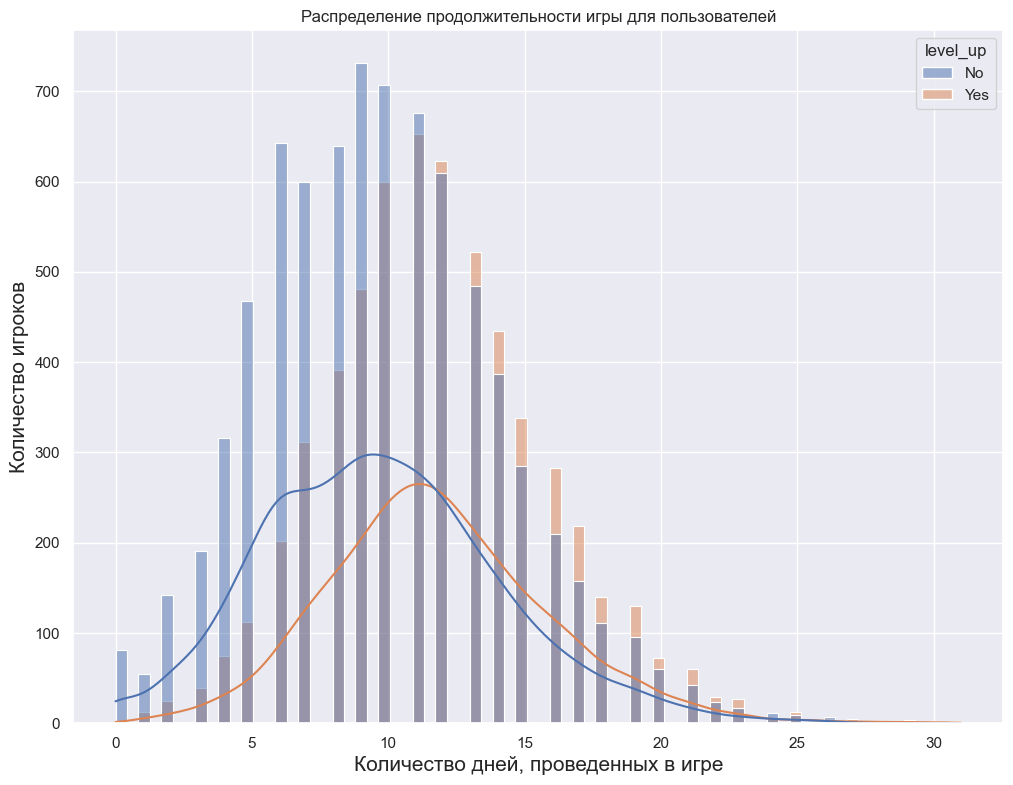

```python
ax = sns.histplot(data=df_users,
                 x="life_time",
                 hue='level_up',
                 stat='count',
                 bins='auto',
                 common_bins=True,
                 common_norm=True,
                 multiple='layer',
                 element='bars',
                 fill=True,
                 shrink=1,
                 thresh=0,
                 kde = True,
                 pthresh=None,
                 pmax=None,
                 cbar=True,
                 cbar_ax=None,
                 cbar_kws=None,
                 palette=None,
                 hue_order=None,
                 hue_norm=None,
                 color=None,
                 legend=True,
                 ax=None)

plt.title('Распределение продолжительности игры для пользователей')
ax.set_xlabel('Количество дней, проведенных в игре', fontsize=15)
ax.set_ylabel('Количество игроков', fontsize=15)

plt.show()
```

Пользователи, которые получают первый уровень проводят в игре в среднем в районе 12 дней, те, что не получают - 10, то есть мы можем сразу отметить, что есть значительная часть пользователей, который совсем чуть-чуть не дотянули до левелапа и бросили игру. Возможно это стоит учесть при корректировке игрового баланса.

[figure not shown]

```python
ax = sns.histplot(df_users['num_buildings'])
ax.set_xlabel('Количество построенных зданий', fontsize=15)
ax.set_ylabel('Количество игроков', fontsize=15)
plt.title('Значения CAC в общем по выборке')
plt.show()
```

```python
df_users['roi'] = df_users['num_buildings'] / df_users['acquisition_cost']
```

Рассчитаем наш аналог ROI, в котором вместо выручки с каждого пользователя мы будем использовать число, построенных им зданий.

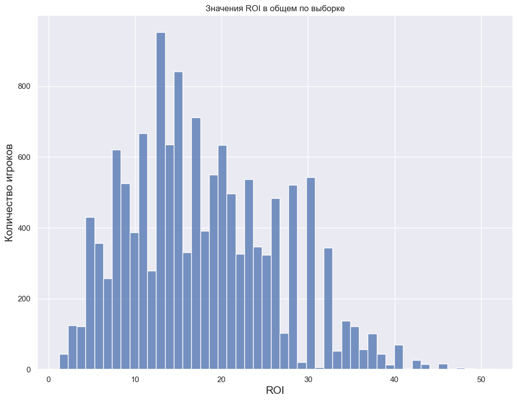

```python
ax = sns.histplot(df_users['roi'])
ax.set_xlabel('ROI', fontsize=15)
ax.set_ylabel('Количество игроков', fontsize=15)
plt.title('Значения ROI в общем по выборке')
plt.show()
```

Отсюда мы видим, что при выручке с каждого показа рекламы в 1$, прибыль будет страшная, однако такой стоимости не бывает. В любом случае получается, что пользователи смотрят рекламу больше 1 раза.

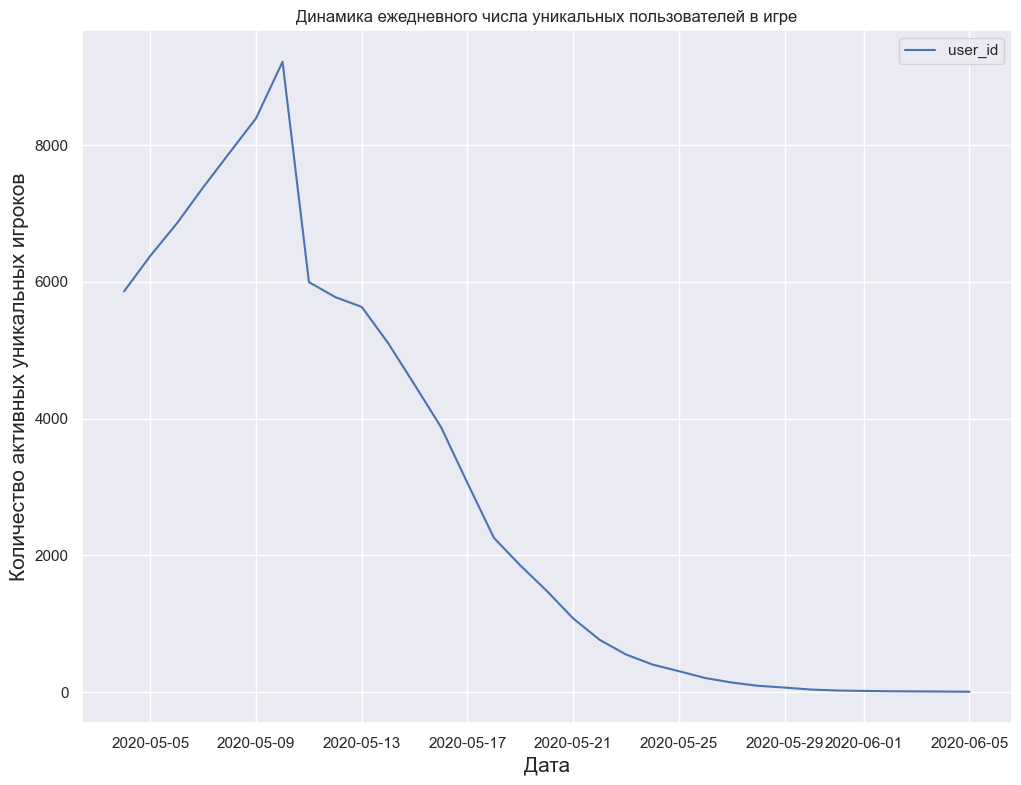

```python
ax = sns.lineplot(data = dau_table)
ax.set_xlabel('Дата', fontsize=15)
ax.set_ylabel('Количество активных уникальных игроков', fontsize=15)
plt.title('Динамика ежедневного числа уникальных пользователей в игре')
plt.show()
```

Вернуться к оглавлению

## Сравнение эффективности рекламных источников

Сравнение когорт игроков, пришедших по разным рекламным каналам по рассчитанным в предыдущем разделе метрикам.

```python
def source_box (value, name):
    ax = sns.boxplot(data = df_users, x = 'source',y = value)
    ax.set_xlabel('Рекламные источники', fontsize=15)
    ax.set_ylabel(name, fontsize=15)
    plt.title('Сравнение переменной "{}" в зависимости от канала привлечения'.format(name))
    plt.show()
```

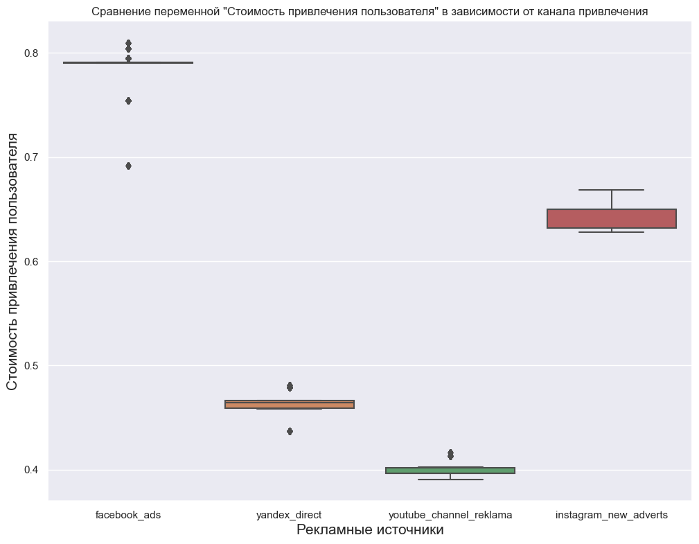

```python
source_box('acquisition_cost', 'Стоимость привлечения пользователя')
```

Итак, мы сразу видим, что фейсбук и инстаграмм - это рекламные источники с заметно более высокой стоимостью привлечения на каждого пользователя.

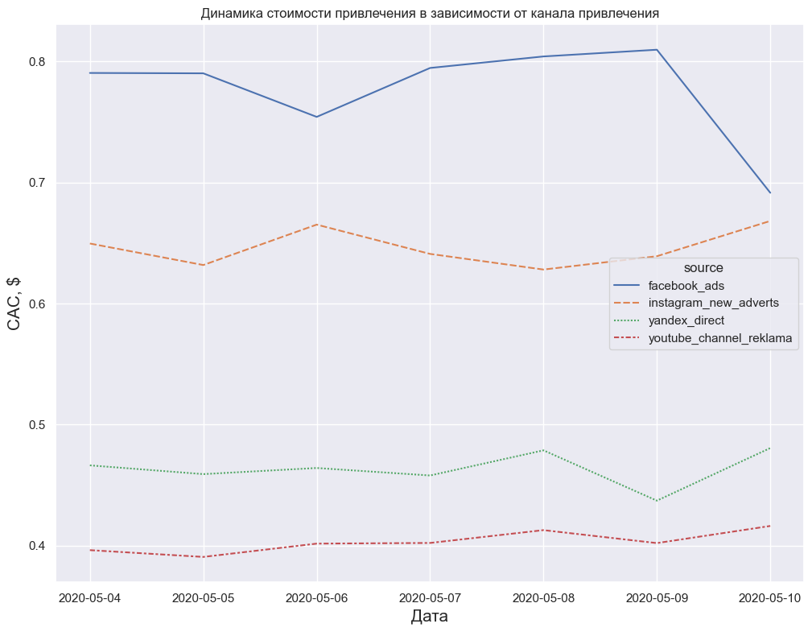

```python
source_acq_dynamic = df_users.pivot_table(index = 'first_action', values = 'acquisition_cost', columns = 'source', aggfunc = 'mean')
ax = sns.lineplot(data = source_acq_dynamic)
ax.set_xlabel('Дата', fontsize=15)
ax.set_ylabel('CAC, $', fontsize=15)
plt.title('Динамика стоимости привлечения в зависимости от канала привлечения')
plt.show()
```

В динамике CAC в разрезе источников сильно не меняется, источники от META сильно дороже, Яндекс директ и Ютуб - сильно дешевле.

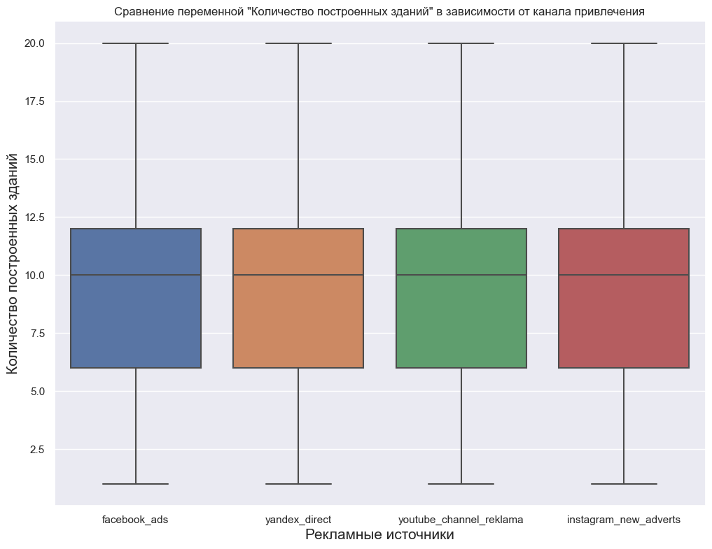

```python
source_box('num_buildings', 'Количество построенных зданий')
```

Количество просмотренной рекламы между пользователями, пришедшими по разным источникам сильно не отличается.

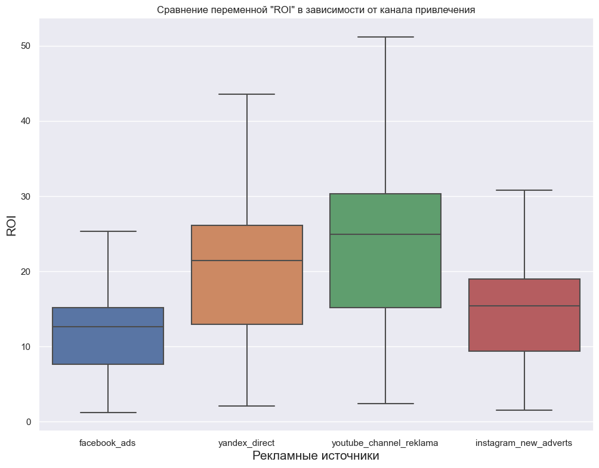

```python
source_box('roi', 'ROI')
```

Самое высокое соотношение числа построенных зданий и стоимости привлечения у Ютуба, затем у Яндекс директа, источники от МЕТА идут с большим отставание.

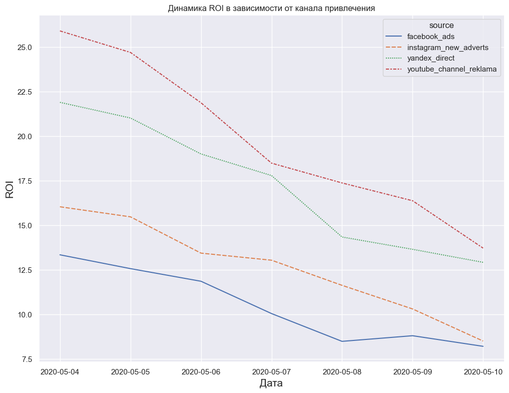

```python
source_dynamic = df_users.pivot_table(index = 'first_action', values = 'roi', columns = 'source', aggfunc = 'mean')
ax = sns.lineplot(data = source_dynamic)
ax.set_xlabel('Дата', fontsize=15)
ax.set_ylabel('ROI', fontsize=15)
plt.title('Динамика ROI в зависимости от канала привлечения')
plt.show()
```

Мы видим, что показатеь ROI значимо падает. При этом графики выше демонстрировали нам, что CAC остается относительно стабильным. Получается падает количество построенных игроками зданий.

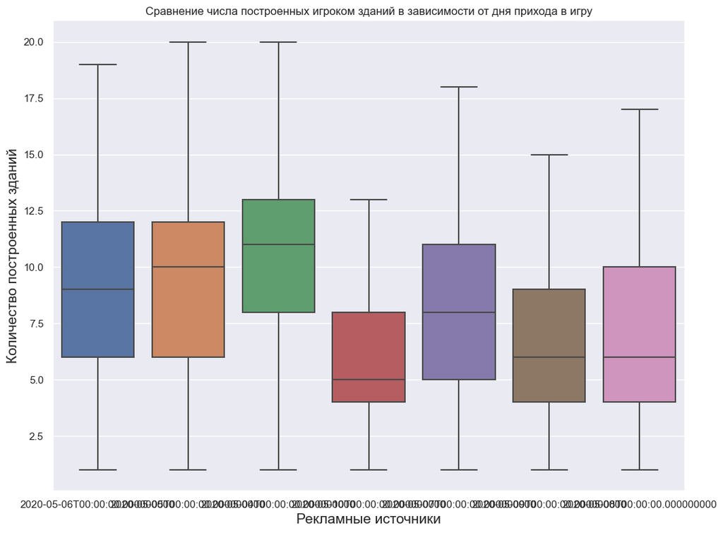

```python
ax = sns.boxplot(data = df_users, x = 'first_action',y = 'num_buildings')
ax.set_xlabel('Рекламные источники', fontsize=15)
ax.set_ylabel('Количество построенных зданий', fontsize=15)
plt.title('Сравнение числа построенных игроком зданий в зависимости от дня прихода в игру')
plt.show()
```

И действительно игроки, пришедшие в игру позже, строят меньше зданий, в связи с чем падает ROI. Данный феномен требует отдельного исследования. Он может быть связан, например, с появлением гайдов по оптимальному строительству.

Изучим отдельно композицию зданий, которые строили игроки разных когорот.

```python
building_composition = df_users[['first_action', 'assembly_shop', 'research_center', 'spaceport']].groupby(by = 'first_action').agg('mean')
building_composition = building_composition.transpose()
display(building_composition)
```

| first_action | 2020-05-04 | 2020-05-05 | 2020-05-06 | 2020-05-07 | 2020-05-08 | 2020-05-09 | 2020-05-10 |
| --- | --- | --- | --- | --- | --- | --- | --- |
| assembly_shop | 4.783 | 4.284 | 3.585 | 2.782 | 2.036 | 1.491 | 1.114 |
| research_center | 1.833 | 1.856 | 1.831 | 1.921 | 1.786 | 1.874 | 1.710 |
| spaceport | 4.504 | 4.468 | 4.449 | 4.485 | 4.504 | 4.476 | 4.445 |

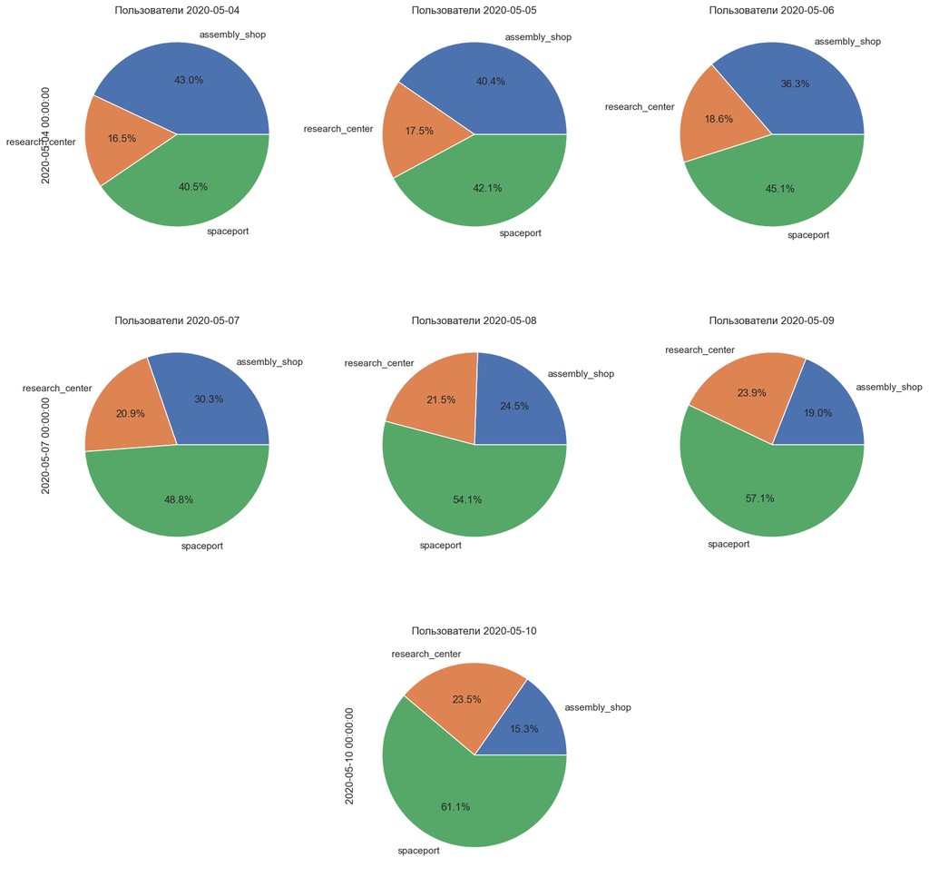

```python
plt.figure(figsize=(45, 45))

ax1 = plt.subplot(3, 3, 1)
building_composition.plot.pie(y='2020-05-04', figsize=(15, 15), autopct="%.1f%%", legend = False, ax=ax1)
plt.title('Пользователи 2020-05-04')

ax2 = plt.subplot(3, 3, 2, sharey=ax1)
building_composition.plot.pie(y='2020-05-05', figsize=(15, 15), autopct="%.1f%%", legend = False, ax=ax2)
plt.title('Пользователи 2020-05-05')

ax3 = plt.subplot(3, 3, 3, sharey=ax1)
building_composition.plot.pie(y='2020-05-06', figsize=(15, 15), autopct="%.1f%%", legend = False, ax=ax3)
plt.title('Пользователи 2020-05-06')

ax4 = plt.subplot(3, 3, 4)
building_composition.plot.pie(y='2020-05-07', figsize=(15, 15), autopct="%.1f%%", legend = False, ax=ax4)
plt.title('Пользователи 2020-05-07')

ax5 = plt.subplot(3, 3, 5, sharey=ax4)
building_composition.plot.pie(y='2020-05-08', figsize=(15, 15), autopct="%.1f%%", legend = False, ax=ax5)
plt.title('Пользователи 2020-05-08')

ax6 = plt.subplot(3, 3, 6, sharey=ax4)
building_composition.plot.pie(y='2020-05-09', figsize=(15, 15), autopct="%.1f%%", legend = False, ax=ax6)
plt.title('Пользователи 2020-05-09')

ax7 = plt.subplot(3, 3, 8)
building_composition.plot.pie(y='2020-05-10', figsize=(15, 15), autopct="%.1f%%", legend = False, ax=ax7)
plt.title('Пользователи 2020-05-10')

plt.tight_layout()
plt.show()
```

```python
display(building_composition.transpose().style.background_gradient('coolwarm'))
```

| first_action | assembly_shop | research_center | spaceport |
| --- | --- | --- | --- |
| 2020-05-04 00:00:00 | 4.783106 | 1.833467 | 4.503934 |
| 2020-05-05 00:00:00 | 4.284439 | 1.855874 | 4.467688 |
| 2020-05-06 00:00:00 | 3.584732 | 1.831437 | 4.448525 |
| 2020-05-07 00:00:00 | 2.781785 | 1.921371 | 4.484793 |
| 2020-05-08 00:00:00 | 2.036337 | 1.786008 | 4.503748 |
| 2020-05-09 00:00:00 | 1.490909 | 1.874074 | 4.475862 |
| 2020-05-10 00:00:00 | 1.114391 | 1.710145 | 4.444867 |

Итак, действительно, мы видим, что пользователи каждой новой когорты строили разные наборы зданий причем тенденции совершенно очевидны - с каждым днем доля сборочных цехов в общем количестве построенных игроками зданий падает, а доли исследовательских центров и особенно космопортов растет. В абсолютных цифрах, которые представлены в таблице выше, мы видим, что число построенных космопортов и исследовательских центров относительно стабильно - пользователи начинают строить меньше сборочных цехов. Очевидно, каждая новая когорта, осваиваясь в игре за счет уже готовых гайдов или по другим причинам, оптимизирует свою стратегию игры в плане строительства, считая, что сборочные цеха не нужны. Так падает число построенных зданий, игроки видят меньше рекламы и оттого падает ROI.

```python
#Создаем сводну таблицу со средними значениями ключевых метрик в разрезе каждого рекламного источника
source_acq = df_users.pivot_table(index = 'source', values = 'acquisition_cost', aggfunc = 'mean')
source_build = df_users.pivot_table(index = 'source', values = 'num_buildings', aggfunc = 'mean')
source_acq = source_acq.reset_index()
source_build = source_build.reset_index()
source = source_acq.merge(source_build, on = 'source')
source['mean_ROI'] = source['num_buildings']/source['acquisition_cost']

source_convert = df_users.pivot_table(index = 'source', columns = 'level_up', values = 'user_id', aggfunc = 'count', margins = True)
source_convert['conversion'] = source_convert['Yes']/source_convert['All']
source_convert = source_convert.reset_index()
source = source.merge(source_convert[['source','conversion']], on = 'source')
```

```python
display(source.style.background_gradient('coolwarm'))
```

|  | source | acquisition_cost | num_buildings | mean_ROI | conversion |
| --- | --- | --- | --- | --- | --- |
| 0 | facebook_ads | 0.785365 | 9.585840 | 12.205588 | 0.421864 |
| 1 | instagram_new_adverts | 0.645785 | 9.505527 | 14.719342 | 0.438004 |
| 2 | yandex_direct | 0.463590 | 9.348557 | 20.165586 | 0.423915 |
| 3 | youtube_channel_reklama | 0.397662 | 9.299330 | 23.385030 | 0.431497 |

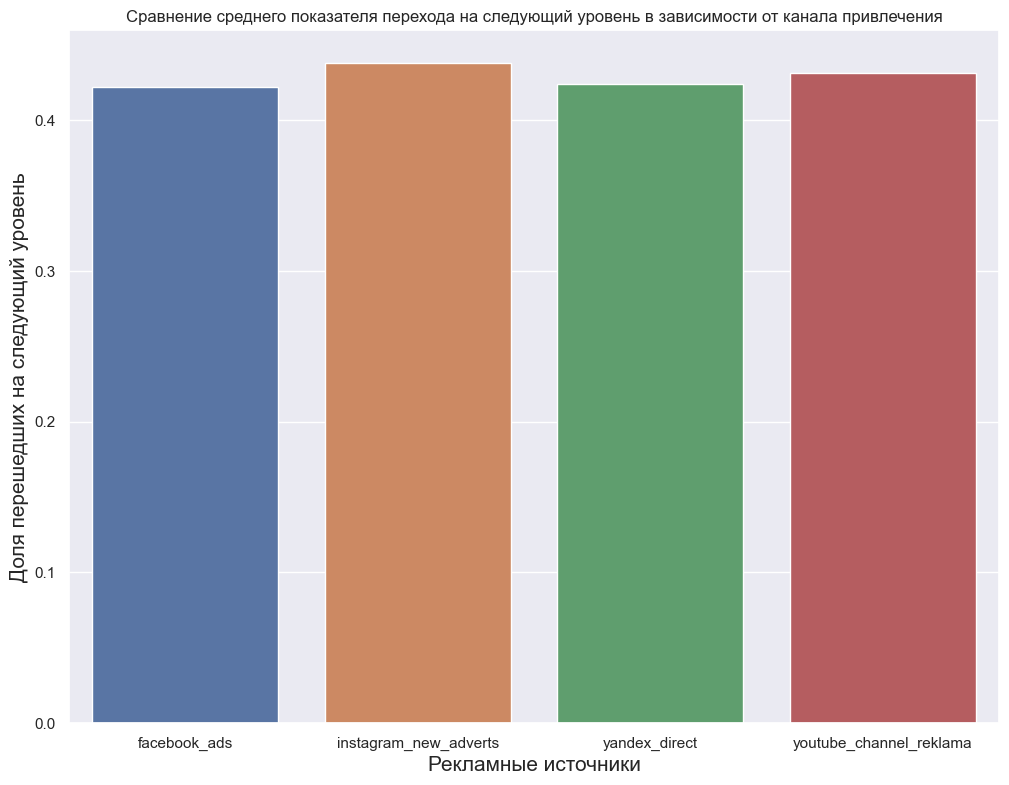

```python
ax = sns.barplot(data = source, y='conversion', x = 'source')
ax.set_xlabel('Рекламные источники', fontsize=15)
ax.set_ylabel('Доля перешедших на следующий уровень', fontsize=15)
plt.title('Сравнение среднего показателя перехода на следующий уровень в зависимости от канала привлечения')
plt.show()
```

Конверсия в левелап между источниками сильно не различается.

**Промежуточный вывод по результатам сравнения рекламных источников:**

- Было обнаружено, что стоимость привлечения игроков через сервисы МЕТА (ФБ и Инста) сильно выше, чем у Яндекса и Ютуба.
- Стоимость привлечения у всех каналов остается относительно стабильной на протяжении исследуемого периода.
- Самый высокий ROI у Ютуба, затем у Яндекса, сервисы МЕТА в конце списка.
- ROI падает со временем - это вызвано изменением в стратегиях строительства, используемых игроками. Сборочный цех становиться все менее нужным для них.
- Показатель конверсии на следующий уровень между рекламными источниками не различается.

Вернуться к оглавлению

## Тестирование исследовательских гипотез

Создадим отдельный массив только из числа тех, кто получил первый уровень.

```python
df_hyp = df_users[df_users['level_up'] == 'Yes']
```

Тестируемые гипотезы будут посвящены сравнению способов прохождения игры до первого уровня.

### Гипотеза №1 (из ТЗ) - время завершения уровня различается в зависимости способа прохождения

Среднее время завершения уровня - достаточно важный показатель. Видеоигра должна регулярно поощрять пользователя новыми достижениями. Как продемонстрировали данные средний лайфтайм пользователей, получивших и не получивших уровень различается всего на несколько дней. То есть если бы они выбрали другой способ прохождения, то могли бы получить уровень и продолжить играть.

**H0:** Среднее количество дней до достижения первого уровня у игроков, выбравших стратегии победы над врагом или выполнения проекта, не отличается.

**H1:** Среднее количество дней до достижения первого уровня у игроков, выбравших стратегии победы над врагом или выполнения проекта, не равны друг другу.

Мы будем использовать параметрический тест - **двусторонний Т-тест Стьюдента.**

```python
alpha = .05

results_users = st.ttest_ind(
    df_hyp['life_time'][df_hyp['type_of_winning'] == 'Defeat_enemy'],
    df_hyp['life_time'][df_hyp['type_of_winning'] == 'Project'],
    equal_var = False)

print('p-значение:', results_users.pvalue)

if results_users.pvalue < alpha:
    print("Отвергаем нулевую гипотезу")
else:
    print("Не получилось отвергнуть нулевую гипотезу")
```

```
p-значение: 6.5704667556440105e-105
Отвергаем нулевую гипотезу
```

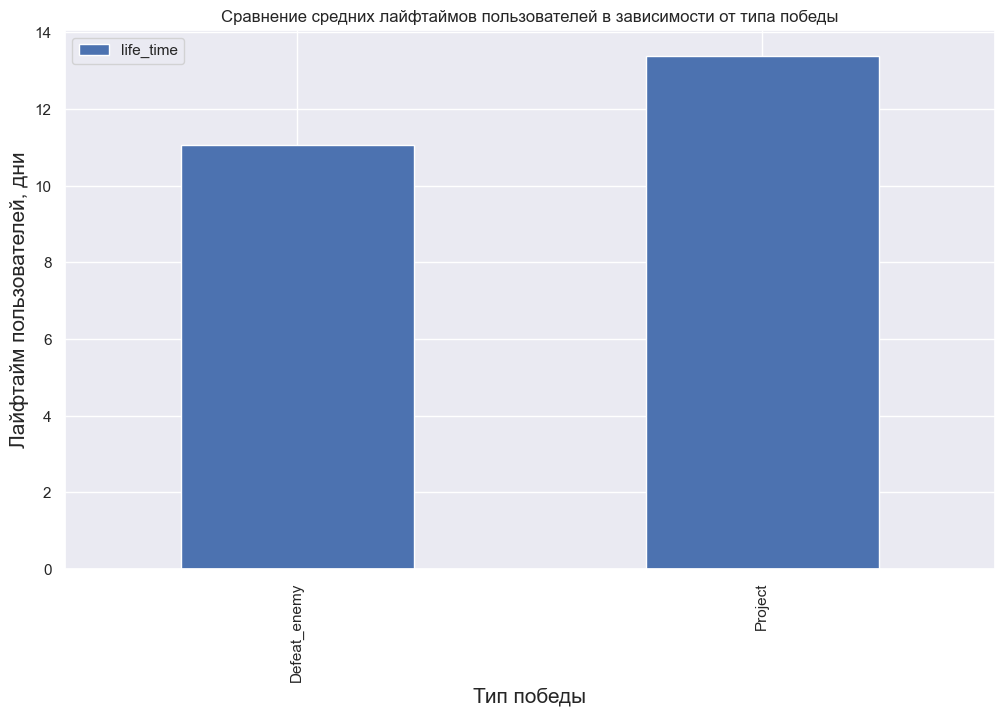

```python
ax = df_hyp.pivot_table(index = 'type_of_winning', values = 'life_time', aggfunc = 'mean').plot.bar(figsize = (12, 7))
ax.set_xlabel('Тип победы', fontsize=15)
ax.set_ylabel('Лайфтайм пользователей, дни', fontsize=15)
plt.title('Сравнение средних лайфтаймов пользователей в зависимости от типа победы')
plt.show()
```

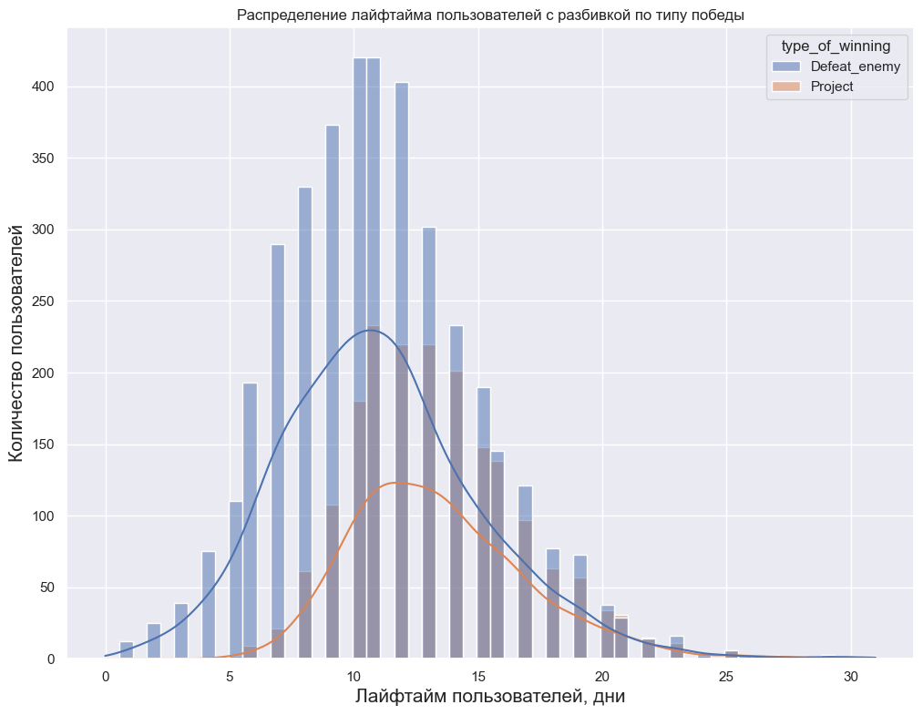

```python
ax = sns.histplot(data=df_hyp,
                 x="life_time",
                 hue='type_of_winning',
                 stat='count',
                 bins='auto',
                 common_bins=True,
                 common_norm=True,
                 multiple='layer',
                 element='bars',
                 fill=True,
                 shrink=1,
                 thresh=0,
                 kde = True,
                 pthresh=None,
                 pmax=None,
                 cbar=True,
                 cbar_ax=None,
                 cbar_kws=None,
                 palette=None,
                 hue_order=None,
                 hue_norm=None,
                 color=None,
                 legend=True,
                 ax=None)

ax.set_xlabel('Лайфтайм пользователей, дни', fontsize=15)
ax.set_ylabel('Количество пользователей', fontsize=15)
plt.title('Распределение лайфтайма пользователей с разбивкой по типу победы')
plt.show()
```

Итак, мы видим, что победа над врагом - это значительно более быстрый способ получения уровня, чем реализация проекта. Собственно предыдущие графики уже показывали нам, что 2/3 игроков делают левелап именно этим способом.

Вернуться к оглавлению

### Гипотеза №2 (авторская) - количество построенных зданий и, соответственно, число просмотренных рекламных объявлений различается в зависимости от способа прохождения

Так как предполагаемая модель монетизации - показ рекламы на экране выбора построек, то количество построенных зданий может служить косвенной метрикой, демонстрирующей, сколько раз игрок заходил на этот экран. Поэтому в случае, если количество построенных зданий у одного из способов прохождения отличается на статистически значимую величину, то имеет смысл скорректировать игровой баланс, дабы значимая часть игроков не проседала по количеству просмотренных рекламных объявлений.

**H0:** Среднее количество построенных зданий до достижения первого уровня у игроков, выбравших стратегии победы над врагом или выполнения проекта, не отличается.

**H1:** Среднее количество построенных зданий до достижения первого уровня у игроков, выбравших стратегии победы над врагом или выполнения проекта, не равны друг другу.

Мы будем использовать параметрический тест - **двусторонний Т-тест Стьюдента.**

```python
alpha = .05

results_users = st.ttest_ind(
    df_hyp['num_buildings'][df_hyp['type_of_winning'] == 'Defeat_enemy'],
    df_hyp['num_buildings'][df_hyp['type_of_winning'] == 'Project'],
    equal_var = False)

print('p-значение:', results_users.pvalue)

if results_users.pvalue < alpha:
    print("Отвергаем нулевую гипотезу")
else:
    print("Не получилось отвергнуть нулевую гипотезу")
```

```
p-значение: 0.0
Отвергаем нулевую гипотезу
```

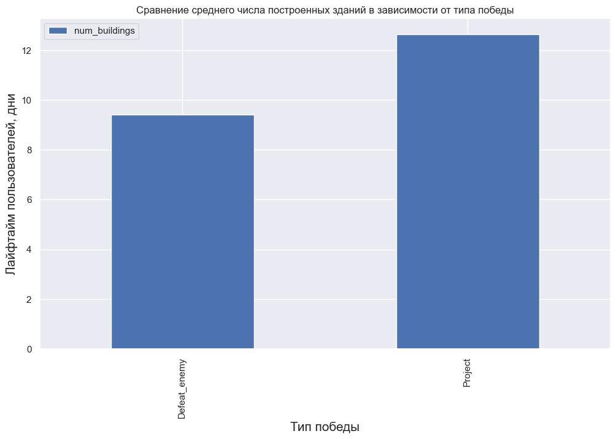

```python
ax = df_hyp.pivot_table(index = 'type_of_winning', values = 'num_buildings', aggfunc = 'mean').plot.bar(figsize = (12, 7))
ax.set_xlabel('Тип победы', fontsize=15)
ax.set_ylabel('Лайфтайм пользователей, дни', fontsize=15)
plt.title('Сравнение среднего числа построенных зданий в зависимости от типа победы')
plt.show()
```

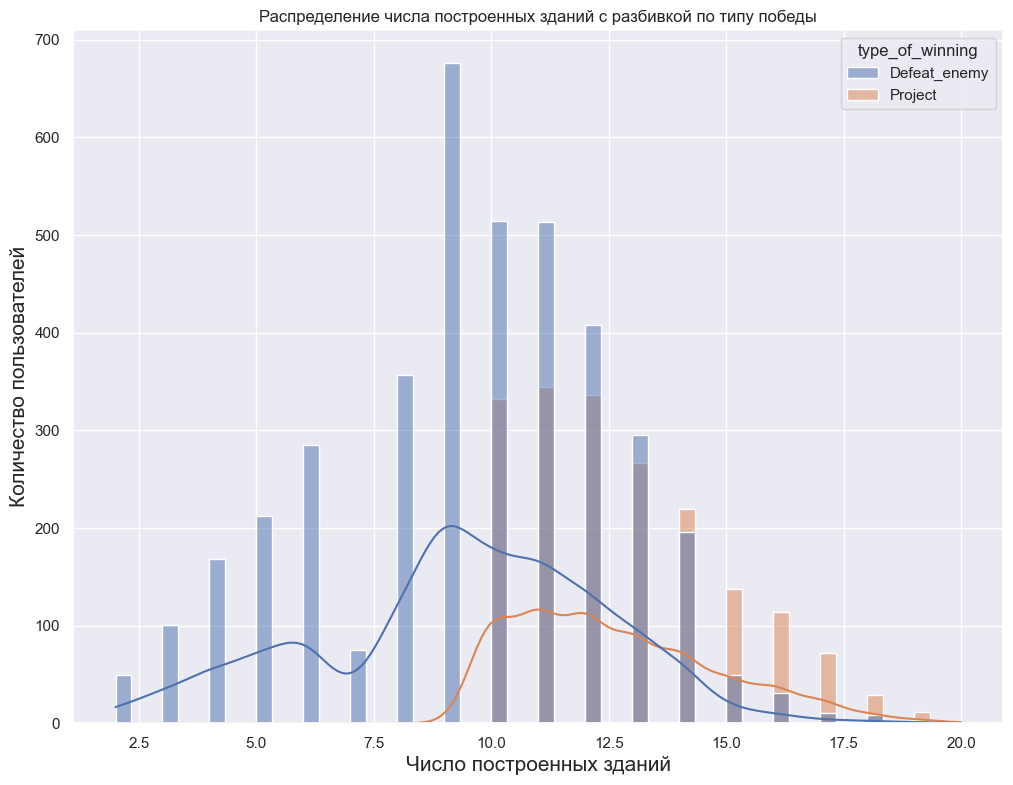

```python
ax = sns.histplot(data=df_hyp,
                 x="num_buildings",
                 hue='type_of_winning',
                 stat='count',
                 bins='auto',
                 common_bins=True,
                 common_norm=True,
                 multiple='layer',
                 element='bars',
                 fill=True,
                 shrink=1,
                 thresh=0,
                 kde = True,
                 pthresh=None,
                 pmax=None,
                 cbar=True,
                 cbar_ax=None,
                 cbar_kws=None,
                 palette=None,
                 hue_order=None,
                 hue_norm=None,
                 color=None,
                 legend=True,
                 ax=None)

ax.set_xlabel('Число построенных зданий', fontsize=15)
ax.set_ylabel('Количество пользователей', fontsize=15)
plt.title('Распределение числа построенных зданий с разбивкой по типу победы')
plt.show()
```

Однако, что важно, игроки, получающие уровень через выполнение проекта при этом строят больше зданий и, соответственно, видят больше рекламы, то есть приносят больше выручки.

Вернуться к оглавлению

## Итоговые выводы и рекомендации

**Общие выводы по результатам анализа:**

- Анализировались данные об активности 13,5 тыс. пользователей, пришедщих с 4 по 10 мая по 4 рекламным источникам.
- 43% пользователей достигли первого уровня и продолжили играть что можно считать хорошим результатом.
- 2/3 пользователей выбирали способ получения уровня через победу на врагом.
- Стоимость привлечения каждого пользователя сильно выше у ФБ и Инстаграмма, ниже у Яндекс Директа и Ютуба.
- Количество построенных зданий сильно не отличается между источниками, но меняется по дням.
- Число построенных зданий падает, потому что игроки строят все меньше зданий типа "сборочный цех", из-за этого падает ROI при стбаильном CAC у всех каналов привлечения.
- Была обнаружена незначительная разница игрового времени между получившими уровень и теми, кто бросил игру до этого момента, то есть если бы уровень можно было бы получить несколько раньше, вероятность сохранения этих клиентов могла бы возрасти.
- Были протестированы гипотезы о разнице среднего игрового времени и среднего количества построенных зданий в зависимости от способа прохождения. В итоге было выявлено, что пользователи, проходящие первый уровень через реализацию проекта играют дольше, но при этом смотрят и больше рекламы.

**Рекомендации заказчику:**

- Оптимальные источнкии для вложения рекламных бюджетов - Яндекс Директ и ЮТуб.
- Возможно потребуется исправить игровой дисбаланс между способами прохождения. Может быть прохождение через проект хоть и будет приносить потенциально больше рекламных денег, скорее оттолкнет игроков длинным временем прохождения.
- Геймдизайнерам необходимо изучить причины, по которым игроки строят все меньше зданий типа "сборочный цех", возможно они считают их бесполезными. Это требует корректировки внутригрового баланса. Рекомендуется проведение внутреннее тестирование силами тестировщиков клиента, возможен опрос пользователей.
- **Рекомендуем провести эксперимент (A|B тестирование)** на тестовой группе протестировать ускоренный сценарий прохождения уровня через проект, чтобы понять, повысит ли это конверсию игроков на следующий уровень и увеличит ли продолжительность их игры, а также приведет ли это в конечном счете к росту ROI.

Вернуться к оглавлению